# HDT1 Análisis exploratorio de datos

Cristopher Barrios, Carlos Daniel Estrada

3/2/2023

```r
library(dplyr)
```

```r
library(ggplot2)
library(tidyr)

datos <- read.csv("movies.csv")
```

### 1. (3 puntos) Haga una exploración rápida de sus datos, para eso haga un resumen de su conjunto de datos.

```r
summary(datos)
```

```
##        id             budget             genres            homePage
##  Min.   :     5   Min.   :        0   Length:10000       Length:10000
##  1st Qu.: 12286   1st Qu.:        0   Class :character   Class :character
##  Median :152558   Median :   500000   Mode  :character   Mode  :character
##  Mean   :249877   Mean   : 18551632
##  3rd Qu.:452022   3rd Qu.: 20000000
##  Max.   :922260   Max.   :380000000
##  productionCompany  productionCompanyCountry productionCountry
##  Length:10000       Length:10000             Length:10000
##  Class :character   Class :character         Class :character
##  Mode  :character   Mode  :character         Mode  :character
##
##
##
##     revenue             runtime        video           director
##  Min.   :0.000e+00   Min.   :  0.0   Mode :logical   Length:10000
##  1st Qu.:0.000e+00   1st Qu.: 90.0   FALSE:9430      Class :character
##  Median :1.631e+05   Median :100.0   TRUE :84        Mode  :character
##  Mean   :5.674e+07   Mean   :100.3   NA's :486
##  3rd Qu.:4.480e+07   3rd Qu.:113.0
##  Max.   :2.847e+09   Max.   :750.0
##     actors          actorsPopularity   actorsCharacter    originalTitle
##  Length:10000       Length:10000       Length:10000       Length:10000
##  Class :character   Class :character   Class :character   Class :character
##  Mode  :character   Mode  :character   Mode  :character   Mode  :character
##
##
##
##     title           originalLanguage     popularity        releaseDate
##  Length:10000       Length:10000       Min.   :    4.258   Length:10000
##  Class :character   Class :character   1st Qu.:   14.578   Class :character
##  Mode  :character   Mode  :character   Median :   21.906   Mode  :character
##                                        Mean   :   51.394
##                                        3rd Qu.:   40.654
##                                        Max.   :11474.647
##     voteAvg         voteCount      genresAmount    productionCoAmount
##  Min.   : 1.300   Min.   :    1   Min.   : 0.000   Min.   : 0.000
##  1st Qu.: 5.900   1st Qu.:  120   1st Qu.: 2.000   1st Qu.: 2.000
##  Median : 6.500   Median :  415   Median : 3.000   Median : 3.000
##  Mean   : 6.483   Mean   : 1342   Mean   : 2.596   Mean   : 3.171
##  3rd Qu.: 7.200   3rd Qu.: 1316   3rd Qu.: 3.000   3rd Qu.: 4.000
##  Max.   :10.000   Max.   :30788   Max.   :16.000   Max.   :89.000
##  productionCountriesAmount  actorsAmount    castWomenAmount
##  Min.   :  0.000           Min.   :     0   Length:10000
##  1st Qu.:  1.000           1st Qu.:    13   Class :character
##  Median :  1.000           Median :    21   Mode  :character
##  Mean   :  1.751           Mean   :  2148
##  3rd Qu.:  2.000           3rd Qu.:    36
##  Max.   :155.000           Max.   :919590
##  castMenAmount
##  Length:10000
##  Class :character
##  Mode  :character
##
##
##
```

### 2. (5 puntos) Diga el tipo de cada una de las variables (cualitativa ordinal o nominal, cuantitativa continua, cuantitativa discreta)

```r
NombreDeLaVariables <- c("id", "popularity", "budget", "revenue", "original_title", "originalLanguage", "title", "homePage", "video", "director", "runtime", "genres", "genresAmount", "productionCompany", "productionCoAmount", "productionCompanyCountry", "productionCountry", "productionCountriesAmount", "releaseDate", "voteCount", "voteAvg", "actors", "actorsPopularity", "actorsCharacter", "actorsAmount", "castWomenAmount", "CastMenAmount")

Continua <- c("", "x", "", "x", "", "", "", "", "", "", "x", "", "", "", "x", "", "", "", "", "", "x", "", "", "", "", "", "")
Discreta <- c("x", "", "x", "", "", "", "", "", "", "", "", "", "x", "", "", "", "", "x", "", "x", "", "", "", "", "x", "x", "x")
Nominal <- c("", "", "", "", "x", "x", "x", "x", "x", "x", "", "x", "", "x", "", "x", "x", "", "", "", "", "x", "x", "x", "", "", "")
Ordinal <- c("", "", "", "", "", "", "", "", "", "", "", "", "", "", "", "", "", "", "x", "", "", "", "", "", "", "", "")

DataFrame.NombreDeLaVariables <- data.frame(NombreDeLaVariables, Continua,Discreta,Nominal,Ordinal)

print(DataFrame.NombreDeLaVariables)
```

```
##          NombreDeLaVariables Continua Discreta Nominal Ordinal
## 1                         id                 x
## 2                 popularity        x
## 3                     budget                 x
## 4                    revenue        x
## 5             original_title                         x
## 6           originalLanguage                         x
## 7                      title                         x
## 8                   homePage                         x
## 9                      video                         x
## 10                  director                         x
## 11                   runtime        x
## 12                    genres                         x
## 13              genresAmount                 x
## 14         productionCompany                         x
## 15        productionCoAmount        x
## 16  productionCompanyCountry                         x
## 17         productionCountry                         x
## 18 productionCountriesAmount                 x
## 19               releaseDate                                 x
## 20                 voteCount                 x
## 21                   voteAvg        x
## 22                    actors                         x
## 23          actorsPopularity                         x
## 24           actorsCharacter                         x
## 25              actorsAmount                 x
## 26           castWomenAmount                 x
## 27             CastMenAmount                 x
```

### 3. (6 puntos) Investigue si las variables cuantitativas siguen una distribución normal y haga una tabla de frecuencias de las variables cualitativas. Explique todos los resultados.

Segun lo que hemos investigado y tambien a los conocimientos previos que se han tenido sobre estadistica, se utiliza la curtoses para verificar cuantos datos se encuentran cerca de la media. se determina que las variables cuantitativas tuvieron un coeficiente mayor a uno, (positivo). referencia: https://economipedia.com/definiciones/curtosis.html

Libreria para utilizar la curstosis

```r
#instalar
#install.packages('e1071')
library(e1071)
```

Curtosis de popularidad

```r
popularity = datos$popularity
kurtosis(popularity)
```

```
## [1] 1225.333
```

Curtosis de budget(presupuesto)

```r
budget = datos$budget
kurtosis(budget)
```

```
## [1] 13.20779
```

Curtosis de revenue

```r
revenue = datos$revenue
kurtosis(revenue)
```

```
## [1] 55.89168
```

Curtosis de runtime

```r
runtime = datos$runtime
kurtosis(runtime)
```

```
## [1] 35.52866
```

Curtosis de VoteCount

```r
vote_count = datos$voteCount
kurtosis(vote_count)
```

```
## [1] 22.76501
```

Curtosis de VoteAvg

```r
vote_average = datos$voteAvg
kurtosis(vote_average)
```

```
## [1] 1.484826
```

Curtosis de GenresAmount

```r
GenresA = datos$genresAmount
kurtosis(GenresA)
```

```
## [1] 2.104824
```

Curtosis de productionCoAmount

```r
ProductionCoA = datos$productionCoAmount
kurtosis(ProductionCoA)
```

```
## [1] 140.2735
```

Curtosis de ProductCountriesAmount

```r
ProducCountrieA = datos$productionCountriesAmount
kurtosis(ProducCountrieA)
```

```
## [1] 751.2015
```

Curtosis de ActorsAmount

```r
ActorsA = datos$actorsAmount
kurtosis(ActorsA)
```

```
## [1] 371.0959
```

Curtosis de CastMenAmount

```r
datos$castMenAmount<-as.numeric(datos$castMenAmount)
castMale = datos$castMenAmount
kurtosis(castMale, na.rm = T)
```

```
## [1] 43.90211
```

Curtosis de CastWomenAmount

```r
datos$castWomenAmount<-as.numeric(datos$castWomenAmount)
castWomen = datos$castWomenAmount
kurtosis(castWomen, na.rm = T)
```

```
## [1] 108.6286
```

##### Variables cualitativas tabla de frecuencias

Estas primeras 2 variables si se pueden hacer tablas de frecuencias pero el resto no debido a la cantidad de datos que estas contienen

originalLanguage

```r
table(datos$originalLanguage)
```

```
##
##   ar   bn   ca   cn   cs   da   de   el   en   es   eu   fa   fi   fr   he   hi
##    1    1    1   80    2   27   84    2 7772  425    1    3    8  271    1   27
##   id   is   it   ja   ko   la   ml   ms   nb   nl   no   pl   pt   ro   ru   sr
##   12    4  100  644  167    1    1    1    1   18   28   15   43    2   67    4
##   sv   ta   te   th   tl   tr   uk   zh
##   27    1    5   17    5   10    2  119
```

video

```r
table(datos$video)
```

```
##
## FALSE  TRUE
##  9430    84
```

original_title

```r
#table(datos$originalTitle)
```

title

```r
#table(datos$title)
```

homePage

```r
#table(datos$homePage)
```

director

```r
#table(datos$director)
```

genres

```r
#table(datos$genres)
```

productionCompany

```r
#table(datos$productionCompany)
```

productionCompanyCountry

```r
#table(datos$productionCompanyCountry)
```

productionCountry

```r
#table(datos$productionCountry)
```

releaseDate

```r
#table(datos$releaseDate)
```

actors

```r
#table(datos$actors)
```

actorsPopularity

```r
#table(datos$actorsPopularity)
```

actorsCharacter

```r
#table(datos$actorsCharacter)
```

## 4. Responda las siguientes preguntas:

### 4.1. (3 puntos) ¿Cuáles son las 10 películas que contaron con más presupuesto?

```r
topbudget <- head(order(datos$budget, decreasing = T),n=10)
datos[topbudget, c("title",("budget"))]
```

```
##                                            title    budget
## 717  Pirates of the Caribbean: On Stranger Tides 380000000
## 4711                     Avengers: Age of Ultron 365000000
## 5953                           Avengers: Endgame 356000000
## 164     Pirates of the Caribbean: At World's End 300000000
## 4954                              Justice League 300000000
## 5954                      Avengers: Infinity War 300000000
## 608                             Superman Returns 270000000
## 3792                                     Tangled 260000000
## 7135                               The Lion King 260000000
## 281                                 Spider-Man 3 258000000
```

### 4.2. (3 puntos) ¿Cuáles son las 10 películas que más ingresos tuvieron?

```r
toprevenue <- head(order(datos$revenue, decreasing = T), n=10)
datos[toprevenue,c("title","revenue")]
```

```
##                             title    revenue
## 3211                       Avatar 2847246203
## 5953            Avengers: Endgame 2797800564
## 308                       Titanic 2187463944
## 4948 Star Wars: The Force Awakens 2068223624
## 5954       Avengers: Infinity War 2046239637
## 4915               Jurassic World 1671713208
## 7135                The Lion King 1667635327
## 9050      Spider-Man: No Way Home 1631853496
## 3398                 The Avengers 1518815515
## 5088                    Furious 7 1515047671
```

### 4.3. (3 puntos) ¿Cuál es la película que más votos tuvo?

```r
topcount <- head(order(datos$voteCount, decreasing = T), n=1)
datos[topcount,c("title","voteCount")]
```

```
##          title voteCount
## 3512 Inception     30788
```

### 4.4. (3 puntos) ¿Cuál es la peor película de acuerdo a los votos de todos los usuarios?

La película con la peor votación es: I’m Being Harassed by the Sexiest Man of the Year, pero es importante resaltar que este dato no es del todo certero, ya que unicamente una persona valoró esta cinta.

```r
worstvalue <- head(order(datos$voteAvg, decreasing = F),n=1)
head(datos[worstvalue,c("voteAvg","title")])
```

```
##      voteAvg
## 9787     1.3
##                                                                                 title
## 9787 DAKAICHI -I'm Being Harassed by the Sexiest Man of the Year- The Movie: In Spain
```

### 4.5. (8 puntos) ¿Cuántas películas se hicieron en cada año? ¿En qué año se hicieron más películas? Haga un gráfico de barras

se puede observar que cada vez se hacen mas peliculas conforme pasa el tiempo esto debe ser por la facilidad que ahora se tienen con las camaras y el audio conforme la tecnologia va avanzando.

El año que se hicieron mas peliculas es en 2020

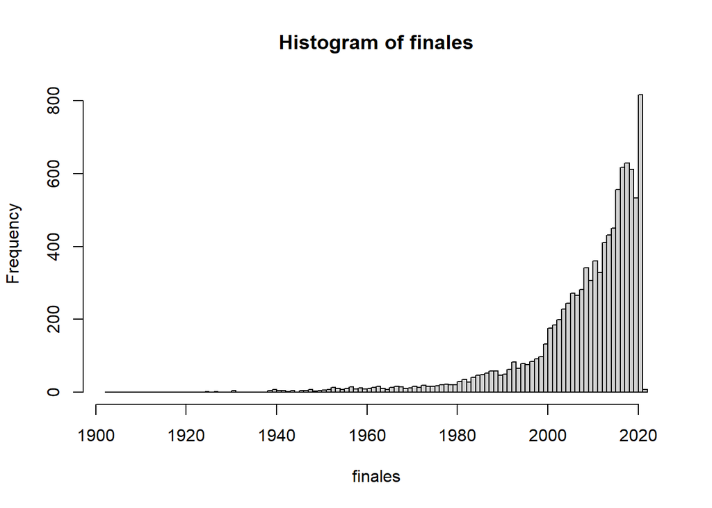

```r
#title, titulo
#releaseDAte, fecha de lanzamiento
Dates <- data.frame(datos$title, datos$releaseDate)
PorAnioDesc <- data.frame(Dates[order(Dates$datos.releaseDate),])
year1 <- data.frame(table(substring(PorAnioDesc$datos.releaseDate,1,4)))
finales <- as.numeric(substring(PorAnioDesc$datos.releaseDate,1,4))
hist(finales,breaks = 100)
```

### 4.6. (9 puntos) ¿Cuál es el género principal de las 20 películas más recientes? ¿Cuál es el género principal que predomina en el conjunto de datos? Represéntelo usando un gráfico

```r
LicaPopular <- datos[order(datos$popularity,decreasing = TRUE),]
top20 <- LicaPopular[1:20,c("genres")]
genres20 <- unlist(strsplit(as.character(top20), "\\|"))
genres20
```

```
##  [1] "Action"          "Adventure"       "Fantasy"         "Science Fiction"
##  [5] "Action"          "Adventure"       "Science Fiction" "Animation"
##  [9] "Comedy"          "Family"          "Music"           "Horror"
## [13] "Action"          "Science Fiction" "Animation"       "Comedy"
## [17] "Family"          "Fantasy"         "Comedy"          "Fantasy"
## [21] "Adventure"       "Action"          "Thriller"        "Science Fiction"
## [25] "Action"          "Adventure"       "Science Fiction" "Action"
## [29] "Adventure"       "Science Fiction" "Thriller"        "Action"
## [33] "Thriller"        "Action"          "Comedy"          "Crime"
## [37] "Thriller"        "Action"          "Adventure"       "Fantasy"
## [41] "Action"          "Thriller"        "Crime"           "Drama"
## [45] "Horror"          "Mystery"         "Animation"       "Comedy"
## [49] "Family"          "Crime"           "Action"          "Thriller"
## [53] "Animation"       "Action"          "Adventure"       "Fantasy"
## [57] "Drama"           "History"         "Adventure"       "Horror"
## [61] "Thriller"
```

El genero principal de las peliculas es:

```r
getmode <- function(v) {
  uniqv <- unique(v)
  uniqv[which.max(tabulate(match(v, uniqv)))]
}

topGenre20 <- getmode(genres20)
topGenre20
```

```
## [1] "Action"
```

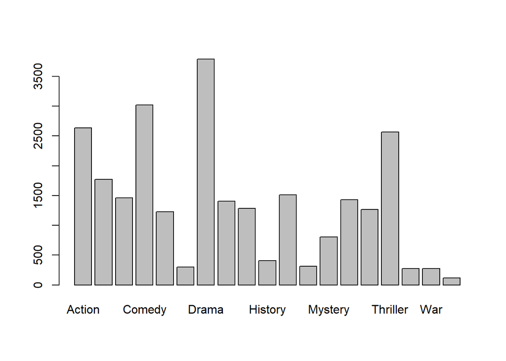

```r
totalGenres <- unlist(strsplit(as.character(datos$genres), "\\|"))
barplot(table(totalGenres))
```

### 4.7. (8 puntos) ¿Las películas de qué genero principal obtuvieron mayores ganancias?

Las peliculas del genero de accion fueron las que obtuvieron mayores ganancias

```r
worth <- data.frame(datos$revenue, datos$genres, datos$title)
ordenadas <- data.frame(worth[order(-datos$revenue), ])

head(ordenadas, 5)
```

```
##      datos.revenue                             datos.genres
## 3211    2847246203 Action|Adventure|Fantasy|Science Fiction
## 5953    2797800564         Adventure|Science Fiction|Action
## 308     2187463944                            Drama|Romance
## 4948    2068223624 Action|Adventure|Science Fiction|Fantasy
## 5954    2046239637         Adventure|Action|Science Fiction
##                       datos.title
## 3211                       Avatar
## 5953            Avengers: Endgame
## 308                       Titanic
## 4948 Star Wars: The Force Awakens
## 5954       Avengers: Infinity War
```

### 4.8. (3 puntos) ¿La cantidad de actores influye en los ingresos de las películas?¿se han hecho películas con más actores en los últimos años?

Como se puede apreciar parece que no influye, ya que avatar tiene menos actores y es la que tiene mas ingresos y luego le sigue avengers que tienen mas actores, pero estan en segundo lugar.

```r
revenueByMovie <- order(datos$revenue, decreasing = T)
head(datos[revenueByMovie,c("actorsAmount","revenue","title")])
```

```
##      actorsAmount    revenue                        title
## 3211           37 2847246203                       Avatar
## 5953          103 2797800564            Avengers: Endgame
## 308           116 2187463944                      Titanic
## 4948          188 2068223624 Star Wars: The Force Awakens
## 5954           65 2046239637       Avengers: Infinity War
## 4915           48 1671713208               Jurassic World
```

### 4.9. (3 puntos) ¿Es posible que la cantidad de hombres y mujeres en el reparto influya en la popularidad y los ingresos de las películas?

Se ha llegado a la conclusion de que la cantidad de actores tanto de hombres como de mujeres no es un factor que influya notablemente los ingresos y la popularidad

```r
#mujeres
womenMoviePopularity <- order(datos$popularity, decreasing = T)
womenMovieRevenue <- order(datos$revenue, decreasing = T)

#hombres
menMoviePopularity <- order(datos$popularity, decreasing = T)
menMovieRevenue <- order(datos$revenue, decreasing = T)
```

Vemos que son menos los actores en la primera pelicula y es mas popular, luego se puede ver de que la siguiente pelicula tiene mas actores tanto hombres como mujeres y es menos popular, luego parece que hay una correlacion entre el numero de actores y la popularidad pero luego el ultimo se pierde esa correlacion

```r
head(datos[womenMoviePopularity,c("castWomenAmount","popularity")])
```

```
##      castWomenAmount popularity
## 8226              11  11474.647
## 9050              13   8443.740
## 7353               8   6055.643
## 7615               9   5887.379
## 8557               9   5804.441
## 7180              12   5051.222
```

```r
head(datos[menMoviePopularity,c("castMenAmount","popularity")])
```

```
##      castMenAmount popularity
## 8226            25  11474.647
## 9050            33   8443.740
## 7353            13   6055.643
## 7615            10   5887.379
## 8557             9   5804.441
## 7180            18   5051.222
```

vemos un orden similar en los primeros de las mujeres con el punto anterior, pero en el de los hombres vemos que no hay una correlacion entre las ganancias y actores.

```r
head(datos[womenMovieRevenue,c("castWomenAmount","revenue")])
```

```
##      castWomenAmount    revenue
## 3211               9 2847246203
## 5953              28 2797800564
## 308               27 2187463944
## 4948              24 2068223624
## 5954              21 2046239637
## 4915              13 1671713208
```

```r
head(datos[menMovieRevenue,c("castMenAmount","revenue")])
```

```
##      castMenAmount    revenue
## 3211            21 2847246203
## 5953            62 2797800564
## 308             59 2187463944
## 4948            74 2068223624
## 5954            43 2046239637
## 4915            31 1671713208
```

### 4.10. (8 puntos) ¿Quiénes son los directores que hicieron las 20 películas mejor calificadas?

Estas son las veinte peliculas mas calificadas, podemos observar que hay peliculas donde no hay directores, esto puede ser de que sean anonimos, y tambien hay en una pelicula que al juzgar por los nombres es una pelicula coreana que tiene bastantes directores

```r
topvotesDirector <- order(datos$voteAvg, decreasing = T)
head(datos[topvotesDirector,c("director","voteAvg")], n =20)
```

```
##                                                                                         director
## 8633                                                                                Thomas Coven
## 9085                                                               V\xedctor Barba|Juan Olivares
## 9247                                                                               Rebecca Sugar
## 9299                                                                           Laurent Bouzereau
## 9348                                                                                Kaku Arakawa
## 9734                                                                              Christin Baker
## 9876
## 9991                                                                         Miguel Angel Zavala
## 6751
## 6886                                                      Dave Bullock|Troy Adomitis|Victor Cook
## 6171                                                                                Samuel Leong
## 7318
## 7454
## 9369                                                                              Won Myeong-jun
```

[output cut: 27 more lines]

### 4.11. (8 puntos) ¿Cómo se correlacionan los presupuestos con los ingresos? ¿Los altos presupuestos significan altos ingresos? Haga los gráficos que necesite, histograma, diagrama de dispersión

Películas con más ingresos

```r
gananciasVSpresupuesto <- order(datos$revenue, decreasing = T)
head(datos[gananciasVSpresupuesto,c("budget","revenue","title")])
```

```
##         budget    revenue                        title
## 3211 237000000 2847246203                       Avatar
## 5953 356000000 2797800564            Avengers: Endgame
## 308  200000000 2187463944                      Titanic
## 4948 245000000 2068223624 Star Wars: The Force Awakens
## 5954 300000000 2046239637       Avengers: Infinity War
## 4915 150000000 1671713208               Jurassic World
```

Películas con más presupuesto

```r
gananciasVSpresupuesto <- order(datos$budget, decreasing = T)
head(datos[gananciasVSpresupuesto,c("budget","revenue","title")])
```

```
##         budget    revenue                                       title
## 717  380000000 1045713802 Pirates of the Caribbean: On Stranger Tides
## 4711 365000000 1405403694                     Avengers: Age of Ultron
## 5953 356000000 2797800564                           Avengers: Endgame
## 164  300000000  961000000    Pirates of the Caribbean: At World's End
## 4954 300000000  657924295                              Justice League
## 5954 300000000 2046239637                      Avengers: Infinity War
```

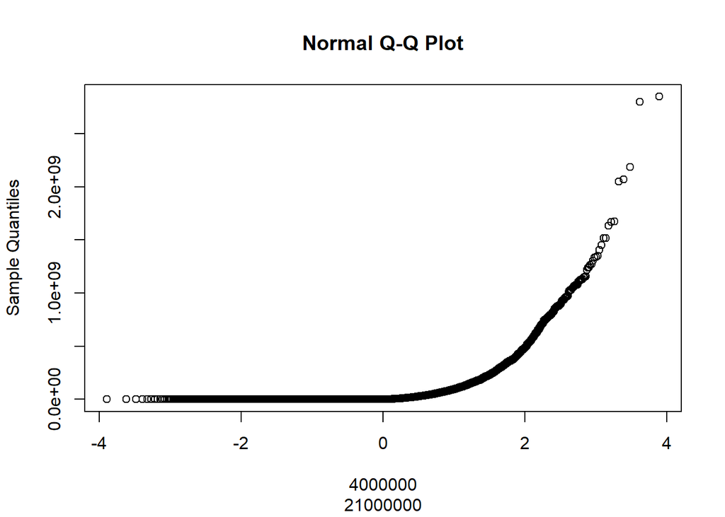

```r
qqnorm(x = datos$budget, y = datos$revenue)
```

### 4.12. (7 puntos) ¿Se asocian ciertos meses de lanzamiento con mejores ingresos?

```r
date <- datos %>% separate(releaseDate, c("y", "m", "d"), sep = "-")
gananciasVSpresupuesto <- order(date$m, decreasing = T)
head(date[gananciasVSpresupuesto,c("m","revenue","title")],)
```

```
##     m   revenue                                             title
## 1  12   4257354                                        Four Rooms
## 23 12 168841459                                    Twelve Monkeys
## 28 12 216763646                               Million Dollar Baby
## 32 12 101371017                                     Mars Attacks!
## 60 12  66023329                                          Scarface
## 67 12 871368364 The Lord of the Rings: The Fellowship of the Ring
```

### 4.13. (8 puntos) ¿En qué meses se han visto los lanzamientos con mejores ingresos?¿cuantas películas, en promedio, se han lanzado por mes?

Según la tabla siguiente, el mes de septiembre es el mes donde se estrenan más películas

```r
sort(table(date$m), TRUE)
```

```
##
##   09   10   12   08   06   03   07   11   02   05   04   01
## 1079 1068  935  913  819  815  812  807  706  698  696  652
```

```r
#date <- datos %>% separate(releaseDate, c("y", "m", "d"), sep = "-")
#r <- order(date$revenue, decreasing = T)
#head(date[r,c("m","revenue","title")],)
```

### 4.14. (7 puntos) ¿Cómo se correlacionan las calificaciones con el éxito comercial?

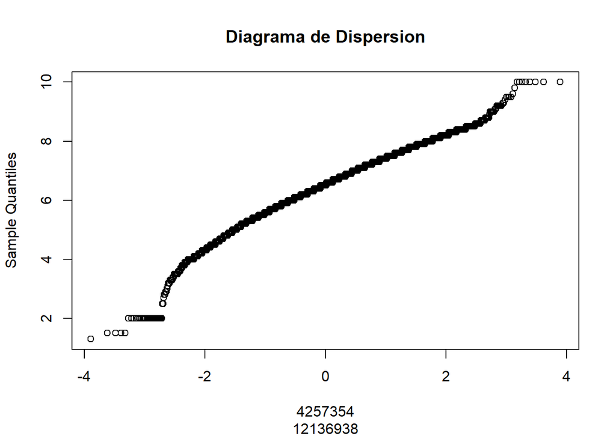

```r
#ingresos <- data.frame(datos$budget, datos$revenue, datos$originalTitle)
#correlacion <- data.frame(datos$revenue, datos$voteCount, datos$originalTitle)
#plot(correlacion[,2], ingresos[,1], main="Diagrama de Dispersion", xlab="voteCount", ylab="Revenue")
#abline(lm(ingresos[,1]~correlacion[,2]), col="blue")

qqnorm(y = datos$voteAvg, x = datos$revenue, main="Diagrama de Dispersion")
```

### 4.15. (5 puntos) ¿A qué género principal pertenecen las películas más largas?

El genero Documental es el que pertenece a las producciones mas largas

```r
duracion <- order(datos$runtime, decreasing = T)
head(datos[duracion,c("runtime","genres","title")])
```

```
##      runtime                genres
## 9348     750           Documentary
## 5359     400           Documentary
## 3886     333     Drama|History|War
## 963      317         Drama|History
## 1264     248 Drama|History|Romance
## 7066     247 Action|Crime|Thriller
##                                                               title
## 9348          How Ponyo was Born ~Hayao Miyazaki's Thought Process~
## 5359 Crystal Lake Memories: The Complete History of Friday the 13th
## 3886                                                       Napoleon
## 963                                                            1900
## 1264                                                      Cleopatra
## 7066                             Kill Bill: The Whole Bloody Affair
```